# W3cubDocs

/Matplotlib 3.1

# matplotlib.axes.Axes.annotate

**`Axes.annotate(self, s, xy, *args, **kwargs)` [[source]](https://matplotlib.org/3.1.1/_modules/matplotlib/axes/_axes.html#Axes.annotate)**

Annotate the point *xy* with text *text*.

In the simplest form, the text is placed at *xy*.

Optionally, the text can be displayed in another position *xytext*. An arrow pointing from the text to the annotated point *xy* can then be added by defining *arrowprops*.

Parameters:

**`text : str`**

The text of the annotation. *s* is a deprecated synonym for this parameter.

**`xy : (float, float)`**

The point *(x,y)* to annotate.

**`xytext : (float, float), optional`**

The position *(x,y)* to place the text at. If *None*, defaults to *xy*.

**`xycoords : str, Artist, Transform, callable or tuple, optional`**

The coordinate system that *xy* is given in. The following types of values are supported:

- One of the following strings:

  | Value | Description |
  | --- | --- |
  | 'figure points' | Points from the lower left of the figure |
  | 'figure pixels' | Pixels from the lower left of the figure |
  | 'figure fraction' | Fraction of figure from lower left |
  | 'axes points' | Points from lower left corner of axes |
  | 'axes pixels' | Pixels from lower left corner of axes |
  | 'axes fraction' | Fraction of axes from lower left |
  | 'data' | Use the coordinate system of the object being annotated (default) |
  | 'polar' | *(theta,r)* if not native 'data' coordinates |

- An `Artist`: *xy* is interpreted as a fraction of the artists `Bbox`. E.g. *(0, 0)* would be the lower left corner of the bounding box and *(0.5, 1)* would be the center top of the bounding box.
- A `Transform` to transform *xy* to screen coordinates.
- A function with one of the following signatures:

  ```
  def transform(renderer) -> Bbox
  def transform(renderer) -> Transform
  ```

  where *renderer* is a `RendererBase` subclass.

  The result of the function is interpreted like the `Artist` and `Transform` cases above.
- A tuple *(xcoords, ycoords)* specifying separate coordinate systems for *x* and *y*. *xcoords* and *ycoords* must each be of one of the above described types.

See [Advanced Annotation](https://matplotlib.org/3.1.1/tutorials/text/annotations.html#plotting-guide-annotation) for more details.

Defaults to 'data'.

**`textcoords : str, Artist, Transform, callable or tuple, optional`**

The coordinate system that *xytext* is given in.

All *xycoords* values are valid as well as the following strings:

| Value | Description |
| --- | --- |
| 'offset points' | Offset (in points) from the *xy* value |
| 'offset pixels' | Offset (in pixels) from the *xy* value |

Defaults to the value of *xycoords*, i.e. use the same coordinate system for annotation point and text position.

**`arrowprops : dict, optional`**

The properties used to draw a `FancyArrowPatch` arrow between the positions *xy* and *xytext*.

If *arrowprops* does not contain the key 'arrowstyle' the allowed keys are:

| Key | Description |
| --- | --- |
| width | The width of the arrow in points |
| headwidth | The width of the base of the arrow head in points |
| headlength | The length of the arrow head in points |
| shrink | Fraction of total length to shrink from both ends |
| ? | Any key to `matplotlib.patches.FancyArrowPatch` |

If *arrowprops* contains the key 'arrowstyle' the above keys are forbidden. The allowed values of `'arrowstyle'` are:

| Name | Attrs |
| --- | --- |
| `'-'` | None |
| `'->'` | head_length=0.4,head_width=0.2 |
| `'-['` | widthB=1.0,lengthB=0.2,angleB=None |
| `'\|-\|'` | widthA=1.0,widthB=1.0 |
| `'-\|>'` | head_length=0.4,head_width=0.2 |
| `'<-'` | head_length=0.4,head_width=0.2 |
| `'<->'` | head_length=0.4,head_width=0.2 |
| `'<\|-'` | head_length=0.4,head_width=0.2 |
| `'<\|-\|>'` | head_length=0.4,head_width=0.2 |
| `'fancy'` | head_length=0.4,head_width=0.4,tail_width=0.4 |
| `'simple'` | head_length=0.5,head_width=0.5,tail_width=0.2 |
| `'wedge'` | tail_width=0.3,shrink_factor=0.5 |

Valid keys for `FancyArrowPatch` are:

| Key | Description |
| --- | --- |
| arrowstyle | the arrow style |
| connectionstyle | the connection style |
| relpos | default is (0.5, 0.5) |
| patchA | default is bounding box of the text |
| patchB | default is None |
| shrinkA | default is 2 points |
| shrinkB | default is 2 points |
| mutation_scale | default is text size (in points) |
| mutation_aspect | default is 1. |
| ? | any key for `matplotlib.patches.PathPatch` |

Defaults to None, i.e. no arrow is drawn.

**`annotation_clip : bool or None, optional`**

Whether to draw the annotation when the annotation point *xy* is outside the axes area.

- If *True*, the annotation will only be drawn when *xy* is within the axes.
- If *False*, the annotation will always be drawn.
- If *None*, the annotation will only be drawn when *xy* is within the axes and *xycoords* is 'data'.

Defaults to *None*.

**kwargs**

Additional kwargs are passed to `Text`.

Returns:

**`annotation : Annotation`**

See also

**[Advanced Annotation](https://matplotlib.org/3.1.1/tutorials/text/annotations.html#plotting-guide-annotation)**

## Examples using `matplotlib.axes.Axes.annotate`

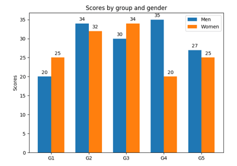

[Grouped bar chart with labels](https://matplotlib.org/3.1.1/gallery/lines_bars_and_markers/barchart.html#sphx-glr-gallery-lines-bars-and-markers-barchart-py)

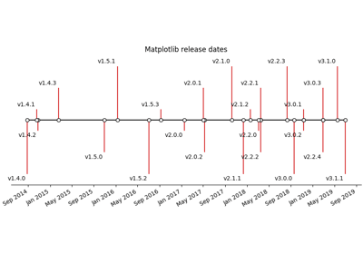

[Creating a timeline with lines, dates, and text](https://matplotlib.org/3.1.1/gallery/lines_bars_and_markers/timeline.html#sphx-glr-gallery-lines-bars-and-markers-timeline-py)

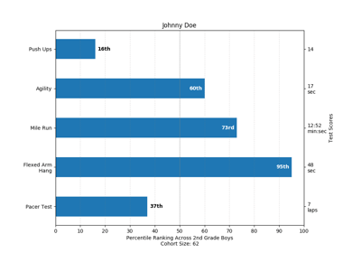

[Percentiles as horizontal bar chart](https://matplotlib.org/3.1.1/gallery/statistics/barchart_demo.html#sphx-glr-gallery-statistics-barchart-demo-py)

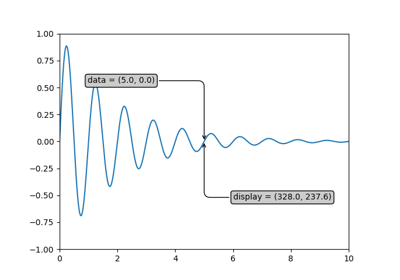

[Annotate Transform](https://matplotlib.org/3.1.1/gallery/pyplots/annotate_transform.html#sphx-glr-gallery-pyplots-annotate-transform-py)

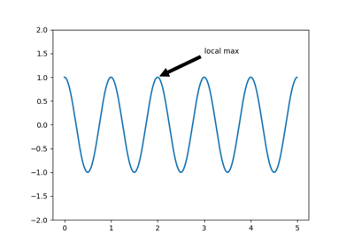

[Annotating a plot](https://matplotlib.org/3.1.1/gallery/pyplots/annotation_basic.html#sphx-glr-gallery-pyplots-annotation-basic-py)

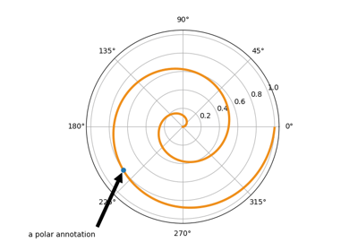

[Annotation Polar](https://matplotlib.org/3.1.1/gallery/pyplots/annotation_polar.html#sphx-glr-gallery-pyplots-annotation-polar-py)

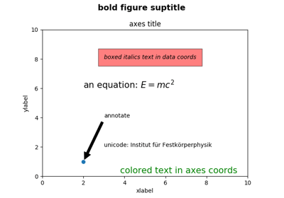

[Text Commands](https://matplotlib.org/3.1.1/gallery/pyplots/text_commands.html#sphx-glr-gallery-pyplots-text-commands-py)

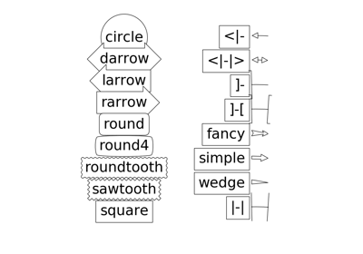

[Whats New 0.98.4 Fancy](https://matplotlib.org/3.1.1/gallery/pyplots/whats_new_98_4_fancy.html#sphx-glr-gallery-pyplots-whats-new-98-4-fancy-py)

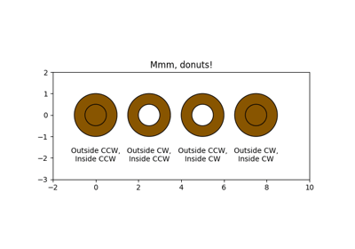

[Mmh Donuts!!!](https://matplotlib.org/3.1.1/gallery/shapes_and_collections/donut.html#sphx-glr-gallery-shapes-and-collections-donut-py)

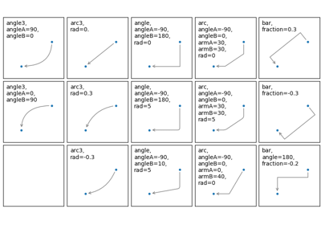

[Connectionstyle Demo](https://matplotlib.org/3.1.1/gallery/userdemo/connectionstyle_demo.html#sphx-glr-gallery-userdemo-connectionstyle-demo-py)

© 2012–2018 Matplotlib Development Team. All rights reserved.  
Licensed under the Matplotlib License Agreement.  
https://matplotlib.org/3.1.1/api/_as_gen/matplotlib.axes.Axes.annotate.html